# Bias Plotting & Analysis

```r
# setwd
setwd('C:/Users/kilda/OneDrive/THESIS/Scripts')
```

```r
#install.packages("installr")
#library("installr")
#installr::updateR()
```

```r
#remove.packages("cli")
#install.packages("cli")

library(dplyr)
library(devtools)

#require(devtools)
#install_version("tidyverse", version = "1.1.1", repos = "http://cran.us.r-project.org ")

library(tidyverse)
library(stringr)
library(data.table)
library(ggplot2)
library(RColorBrewer)
library(readr)

#devtools::install_github('cttobin/ggthemr')
library(ggthemr)
```

```r
data_bias <- read_csv("dataset_final_google.csv")
#data_bias1 <- read_csv("dataset_final_merged2.csv")

#data_gd_glove <- read_csv("gender_bias_dict_glove.csv")
```

```r
data_gd_google <- read_csv("gender_bias_dict_google.csv")
newdata <- data_gd_google[ which(data_gd_google$Bias > '-1000'), ]
length(newdata$Bias)
```

```
[1] 10680
```

```r
newdata1 <- data_gd_google %>% filter(data_gd_google$Bias > '-1000.0000000')
```

```r
data_gd_glove <- read_csv("gender_bias_dict_glove.csv")
newdata <- data_gd_glove[ which(data_gd_glove$Bias > '-1000'), ]

length(newdata$Bias)
```

```
[1] 14112
```

```r
## gender dictionary after merging extra data in

data_gd_merged <- read_csv("gender_bias_dict_merged2.csv")
newdata3 <- data_gd_merged[ which(data_gd_merged$Bias > '-1000'), ]
length(newdata3$Bias)
```

```
[1] 12364
```

^^ not sure if it’s worth doing this, discuss

```r
## gender bias dictionary - unique words with values before preprocessing was fixed

data_gd_og <- read_csv("gender_bias_dict.csv")
newdata4 <- data_gd_og[ which(data_gd_og$Bias > '-1000'), ]
length(newdata4$Bias)
```

```
[1] 10133
```

```r
# gender bias dictionary using wikipedia pretrain (but all industries become positive) -- wtf?

data_gd_wiki <- read_csv("gender_bias_dict_wiki.csv")
newdata5 <- data_gd_wiki[ which(data_gd_wiki$Bias > '-1000'), ]
length(newdata5$Bias)
```

```r
# gender bias dictionary common crawl model/pretrain - also all positive

data_gd_crawl <- read_csv("gender_bias_dict_crawl.csv")

newdata6 <- data_gd_crawl[ which(data_gd_crawl$Bias > '-1000'), ]

length(newdata6$Bias)
```

## —— Density Plots ——

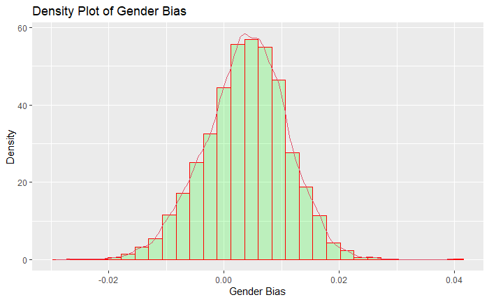

```r
ggplot(data=data_bias, aes(data_bias$man_woman)) +
  geom_histogram(aes(y =..density..),col="red", fill="green", alpha=.2) +
  geom_density(col=2) +
   labs(title="Density Plot of Gender Bias", y = "Density", x = "Gender Bias")
```

```r
NA
NA
NA
```

```r
summary(data_bias$man_woman)
```

```
      Min.    1st Qu.     Median       Mean    3rd Qu.       Max.
-0.0291219 -0.0006779  0.0040916  0.0038072  0.0086316  0.0396817
```

```r
sd(data_bias$man_woman)
```

```
[1] 0.007176687
```

```r
shapiro.test(sample$man_woman)
```

```
    Shapiro-Wilk normality test

data:  sample$man_woman
W = 0.9941, p-value = 1.77e-13
```

### — Top Words Male vs. Female —

Female encoded words -

mothers -0.250502959 women -0.242072433 pregnant -0.235946476 pregnancy -0.233661883 lesbian -0.223894194 breastfeeding -0.223523491 bras -0.220144995 feminine -0.213751659 actresses -0.212869629 gender -0.201855466 lingerie -0.200355515 babies -0.193956211 nurse -0.18663305 swimwear -0.186498873 implants -0.181541555

male endcoded words - wizard 0.218160905 beard 0.196113512 kingpin 0.191584907 buddy 0.188891947 guys 0.186992384 legend 0.177719891 tinkering 0.166542657 whiz 0.164664887 runout 0.157976776 mates 0.157605164 skipper 0.153876863 marshalling 0.153284557 orchestrator 0.153016772 scouting 0.151209559 wingman 0.150607549

```r
summary(lm_occu)
```

[output not shown]

## —— Linear Regression Models —–

```r
summary(lm_occu)
```

```
Call:
lm(formula = man_woman ~ Occupation, data = data_bias)

Residuals:
      Min        1Q    Median        3Q       Max
-0.027303 -0.003627  0.000034  0.003618  0.038830

Coefficients:
                                        Estimate Std. Error t value
(Intercept)                            4.850e-03  2.819e-04  17.208
OccupationAccounting Clerk            -3.592e-03  1.141e-03  -3.148
OccupationActor                        7.721e-04  1.589e-03   0.486
OccupationAdvertising                 -4.929e-03  4.247e-04 -11.607
OccupationAged Care                   -1.130e-02  8.043e-04 -14.054
OccupationAgricultural Science        -2.900e-03  1.084e-03  -2.675
OccupationAir Transport                1.629e-03  8.043e-04   2.025
OccupationAmusement Work               3.783e-03  1.723e-03   2.196
OccupationApplication Programmer       2.024e-03  6.577e-04   3.078
OccupationArchitect                   -1.027e-03  5.868e-04  -1.750
OccupationBaker                        3.614e-03  1.051e-03   3.438
OccupationBarista                      3.243e-03  6.577e-04   4.932
OccupationBartender                    4.689e-03  8.864e-04   5.290
OccupationBookkeeper                   2.284e-03  6.490e-04   3.520
OccupationBricklayer                   8.822e-03  8.954e-04   9.853
OccupationBuilding Labourer            3.475e-03  1.067e-03   3.257
OccupationBuilding Surveyor           -3.762e-03  1.067e-03  -3.525
OccupationBuilding Technician         -1.186e-03  5.060e-04  -2.344
OccupationCabinetmaker                 6.547e-03  1.036e-03   6.322
OccupationCafe Manager                 2.207e-03  7.054e-04   3.128
OccupationCafe Work                    4.942e-03  6.869e-04   7.195
OccupationCarer                       -9.166e-03  6.577e-04 -13.937
OccupationCarpenter                    8.282e-03  1.007e-03   8.224
OccupationCashier                      3.420e-03  1.185e-03   2.887
OccupationCheckout Worker              1.795e-03  6.766e-04   2.653
OccupationChef                         3.239e-03  6.407e-04   5.056
OccupationChemical Plant Worker       -5.961e-04  9.687e-04  -0.615
OccupationChildcare                   -6.305e-03  6.462e-04  -9.758
OccupationCivil Engineer              -4.055e-04  8.611e-04  -0.471
OccupationClerk                       -6.035e-03  3.476e-04 -17.363
OccupationCoach Driver                 8.104e-05  8.310e-04   0.098
```

[output cut: 362 more lines]

```
OccupationTechnical Sales             0.544322
OccupationTechnology                  3.96e-06 ***
OccupationTelecommunications Trade    0.023865 *
OccupationTelevision                  0.001658 **
OccupationTiler                       6.19e-09 ***
OccupationTruck Driver                 < 2e-16 ***
OccupationTutor                       0.015336 *
OccupationVisual Arts                 0.009736 **
 [ reached getOption("max.print") -- omitted 7 rows ]
---
Signif. codes:  0 ‘***’ 0.001 ‘**’ 0.01 ‘*’ 0.05 ‘.’ 0.1 ‘ ’ 1

Residual standard error: 0.005637 on 18348 degrees of freedom
Multiple R-squared:  0.3898,    Adjusted R-squared:  0.383
F-statistic:  56.9 on 206 and 18348 DF,  p-value: < 2.2e-16
```

```r
summary(lm_ind)
```

```
Call:
lm(formula = man_woman ~ Industry, data = data_bias)

Residuals:
      Min        1Q    Median        3Q       Max
-0.028336 -0.004127  0.000032  0.004119  0.039499

Coefficients:
                                                         Estimate
(Intercept)                                             7.837e-03
IndustryAdministrative and Support Services            -4.203e-03
IndustryAgriculture Forestry and Fishing               -2.380e-03
IndustryArts and Recreation Services                   -2.635e-03
IndustryConstruction                                   -1.307e-03
IndustryEducation and Training                         -9.960e-03
IndustryElectricity Gas Water and Waste Services       -1.791e-03
IndustryFinancial and Insurance Services               -5.776e-03
IndustryHealthcare and Social Assistance               -1.159e-02
IndustryInformation Media and Telecommunications       -5.071e-03
IndustryManufacturing                                  -3.398e-05
IndustryMining                                         -1.600e-03
IndustryProfessional Scientific and Technical Services -5.366e-03
IndustryPublic Administration and Safety               -5.854e-03
IndustryRental Hiring and Real Estate Services         -4.396e-03
IndustryRetail Trade                                   -2.967e-03
IndustryTransport Postal and Warehousing               -1.476e-03
IndustryWholesale Trade                                -6.655e-04
                                                       Std. Error t value
(Intercept)                                             1.786e-04  43.890
IndustryAdministrative and Support Services             2.722e-04 -15.438
IndustryAgriculture Forestry and Fishing                3.121e-04  -7.625
IndustryArts and Recreation Services                    2.833e-04  -9.300
IndustryConstruction                                    2.668e-04  -4.898
IndustryEducation and Training                          2.693e-04 -36.981
IndustryElectricity Gas Water and Waste Services        2.948e-04  -6.075
IndustryFinancial and Insurance Services                2.901e-04 -19.913
IndustryHealthcare and Social Assistance                2.415e-04 -47.989
IndustryInformation Media and Telecommunications        2.685e-04 -18.886
IndustryManufacturing                                   2.730e-04  -0.124
IndustryMining                                          2.706e-04  -5.913
```

[output cut: 16 more lines]

```
IndustryInformation Media and Telecommunications        < 2e-16 ***
IndustryManufacturing                                   0.90094
IndustryMining                                         3.42e-09 ***
IndustryProfessional Scientific and Technical Services  < 2e-16 ***
IndustryPublic Administration and Safety                < 2e-16 ***
IndustryRental Hiring and Real Estate Services          < 2e-16 ***
IndustryRetail Trade                                    < 2e-16 ***
IndustryTransport Postal and Warehousing               2.58e-07 ***
IndustryWholesale Trade                                 0.00903 **
---
Signif. codes:  0 ‘***’ 0.001 ‘**’ 0.01 ‘*’ 0.05 ‘.’ 0.1 ‘ ’ 1

Residual standard error: 0.006348 on 18537 degrees of freedom
Multiple R-squared:  0.2183,    Adjusted R-squared:  0.2176
F-statistic: 304.6 on 17 and 18537 DF,  p-value: < 2.2e-16
```

```r
###------ dividing data into female and male bias + transforming female to absolute values to compare means   -----####


data_bias$mf[data_bias$man_woman <= 0] <- "female"
data_bias$mf[data_bias$man_woman >= 0] <- "male"
data_bias$biases <- "male"
data_bias$biases[data_bias$Industry == "Healthcare & Social Assistance" | data_bias$Industry == "Education & Training"] <- "female"
data_bias$absolute <- abs(data_bias$man_woman)
mean(data_bias$absolute[data_bias$mf == "female"])
```

```
[1] 0.004979394
```

```r
mean(data_bias$absolute[data_bias$mf == "male"])
```

```
[1] 0.007200661
```

```r
sd(data_bias$absolute[data_bias$mf == "female"])
```

```
[1] 0.004041835
```

```r
sd(data_bias$absolute[data_bias$mf == "male"])
```

```
[1] 0.004831593
```

```r
data.summary <- data_bias %>%
  group_by(mf) %>%
  summarise(
    sd = sd(absolute, na.rm = TRUE),
    len = mean(absolute)
  )
data.summary
```

| mf | sd | len |
| --- | --- | --- |
| female | 0.004041835 | 0.004979394 |
| male | 0.004831593 | 0.007200661 |

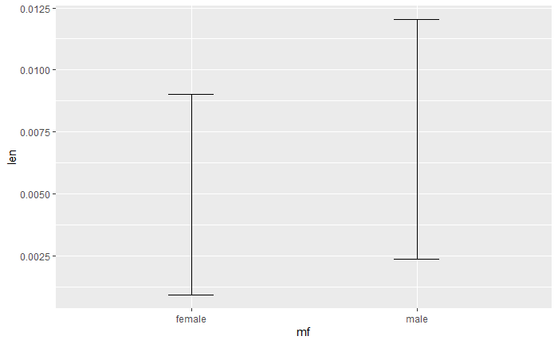

```r
ggplot(data.summary, aes(x = mf, y = len, ymin = len-sd, ymax = len+sd))+
  geom_errorbar(width = 0.2)
```

```r
t.test(data_bias$absolute[data_bias$mf == "male"], data_bias$absolute[data_bias$mf == "female"])
```

```
    Welch Two Sample t-test

data:  data_bias$absolute[data_bias$mf == "male"] and data_bias$absolute[data_bias$mf == "female"]
t = 31.728, df = 11164, p-value < 2.2e-16
alternative hypothesis: true difference in means is not equal to 0
95 percent confidence interval:
 0.002084038 0.002358497
sample estimates:
  mean of x   mean of y
0.007200661 0.004979394
```

```r
in1 <- subset(data_bias, data_bias$Industry == 'Accommodation and Food Services')
summary(in1$man_woman)
```

```
     Min.   1st Qu.    Median      Mean   3rd Qu.      Max.
-0.014318  0.003572  0.008207  0.007837  0.012188  0.029761
```

```r
write.csv(in1,"accomfs.csv")

in22 <- subset(data_bias, data_bias$Industry == 'Administrative and Support Services')
summary(in22$man_woman)
```

```
      Min.    1st Qu.     Median       Mean    3rd Qu.       Max.
-0.0158033 -0.0004576  0.0037862  0.0036334  0.0079882  0.0258837
```

```r
write.csv(in22,"admin.csv")

in2 <- subset(data_bias, data_bias$Industry == 'Agriculture Forestry and Fishing')
summary(in2$man_woman)
```

[output not shown]

```r
write.csv(in2,"agr.csv")

in3 <- subset(data_bias, data_bias$Industry == 'Arts and Recreation Services')
summary(in3$man_woman)
```

```
      Min.    1st Qu.     Median       Mean    3rd Qu.       Max.
-0.0145876  0.0007326  0.0053547  0.0052019  0.0102394  0.0287541
```

```r
write.csv(in3,"arts.csv")

in4 <- subset(data_bias, data_bias$Industry == 'Construction')
summary(in4$man_woman)
```

```
     Min.   1st Qu.    Median      Mean   3rd Qu.      Max.
-0.015803  0.001973  0.006216  0.006530  0.011047  0.039682
```

```r
write.csv(in4,"con.csv")

in5 <- subset(data_bias, data_bias$Industry == 'Education and Training')
summary(in5$man_woman)
```

[output not shown]

```r
write.csv(in5,"edu.csv")

in6 <- subset(data_bias, data_bias$Industry == 'Electricity Gas Water and Waste Services')
summary(in6$man_woman)
```

```
     Min.   1st Qu.    Median      Mean   3rd Qu.      Max.
-0.011492  0.002603  0.005718  0.006045  0.009445  0.025278
```

```r
write.csv(in6,"ele.csv")

in7 <- subset(data_bias, data_bias$Industry == 'Financial and Insurance Services')
summary(in7$man_woman)
```

```
     Min.   1st Qu.    Median      Mean   3rd Qu.      Max.
-0.015803 -0.001690  0.002280  0.002060  0.005987  0.025884
```

```r
write.csv(in7,"fin.csv")

in8 <- subset(data_bias, data_bias$Industry == 'Healthcare and Social Assistance')
summary(in8$man_woman)
```

```
      Min.    1st Qu.     Median       Mean    3rd Qu.       Max.
-0.0291219 -0.0083788 -0.0038088 -0.0037546  0.0004932  0.0212396
```

```r
write.csv(in8,"health.csv")

in9 <- subset(data_bias, data_bias$Industry == 'Information Media and Telecommunications')
summary(in9$man_woman)
```

```
     Min.   1st Qu.    Median      Mean   3rd Qu.      Max.
-0.018467 -0.001438  0.002662  0.002765  0.007310  0.025884
```

```r
write.csv(in9,"info.csv")

in10 <- subset(data_bias, data_bias$Industry == 'Manufacturing')
summary(in10$man_woman)
```

```
     Min.   1st Qu.    Median      Mean   3rd Qu.      Max.
-0.011089  0.004173  0.007897  0.007803  0.011329  0.028220
```

```r
write.csv(in10,"manu.csv")

in11 <- subset(data_bias, data_bias$Industry == 'Mining')
summary(in11$man_woman)
```

```
     Min.   1st Qu.    Median      Mean   3rd Qu.      Max.
-0.006940  0.003008  0.006040  0.006236  0.009376  0.039682
```

```r
write.csv(in11,"mining.csv")

in12 <- subset(data_bias, data_bias$Industry == 'Professional Scientific and Technical Services')
summary(in12$man_woman)
```

```
     Min.   1st Qu.    Median      Mean   3rd Qu.      Max.
-0.018682 -0.001489  0.002614  0.002471  0.006513  0.025884
```

```r
write.csv(in12,"prof.csv")

in13 <- subset(data_bias, data_bias$Industry == 'Public Administration and Safety')
summary(in13$man_woman)
```

```
     Min.   1st Qu.    Median      Mean   3rd Qu.      Max.
-0.023827 -0.002392  0.002271  0.001983  0.006106  0.039682
```

```r
write.csv(in13,"public.csv")

in14 <- subset(data_bias, data_bias$Industry == 'Rental Hiring and Real Estate Services')
summary(in14$man_woman)
```

```
      Min.    1st Qu.     Median       Mean    3rd Qu.       Max.
-0.0167248 -0.0005129  0.0036777  0.0034408  0.0077430  0.0258837
```

```r
write.csv(in14,"rental.csv")

in15 <- subset(data_bias, data_bias$Industry == 'Retail Trade')
summary(in15$man_woman)
```

```
     Min.   1st Qu.    Median      Mean   3rd Qu.      Max.
-0.013356  0.001030  0.005252  0.004870  0.009144  0.025884
```

```r
write.csv(in15,"retail.csv")

in16 <- subset(data_bias, data_bias$Industry == 'Transport Postal and Warehousing')
summary(in16$man_woman)
```

```
     Min.   1st Qu.    Median      Mean   3rd Qu.      Max.
-0.014669  0.002299  0.006481  0.006361  0.010785  0.026541
```

```r
write.csv(in16,"trans.csv")

in17 <- subset(data_bias, data_bias$Industry == 'Wholesale Trade')
summary(in17$man_woman)
```

```
     Min.   1st Qu.    Median      Mean   3rd Qu.      Max.
-0.011549  0.003287  0.007059  0.007171  0.010888  0.025884
```

```r
write.csv(in17,"wholesale.csv")
```

```r
r1 <- subset(data_bias, data_bias$Rating == 'Accommodation and Food Services')
summary(in1$Rating)
```

```
   Min. 1st Qu.  Median    Mean 3rd Qu.    Max.    NA's
  1.600   3.400   3.600   3.658   4.000   5.000     734
```

```r
r2 <- subset(data_bias, data_bias$Rating == 'Agriculture Forestry and Fishing')
summary(in2$Rating)
```

```
   Min. 1st Qu.  Median    Mean 3rd Qu.    Max.    NA's
  1.500   3.400   3.800   3.667   4.000   5.000     332
```

```r
r3 <- subset(data_bias, data_bias$Rating == 'Arts and Recreation Services')
summary(in3$Rating)
```

```
   Min. 1st Qu.  Median    Mean 3rd Qu.    Max.    NA's
  2.500   3.600   3.900   3.862   4.100   5.000     503
```

```r
r4 <- subset(data_bias, data_bias$Rating == 'Construction')
summary(in4$Rating)
```

```
   Min. 1st Qu.  Median    Mean 3rd Qu.    Max.    NA's
  1.000   3.500   3.800   3.709   4.000   5.000     477
```

```r
r5 <- subset(data_bias, data_bias$Rating == 'Education and Training')
summary(in5$Rating)
```

```
   Min. 1st Qu.  Median    Mean 3rd Qu.    Max.    NA's
  1.600   3.500   3.800   3.732   4.000   5.000     534
```

```r
r6 <- subset(data_bias, data_bias$Rating == 'Electricity Gas Water and Waste Services')
summary(in6$Rating)
```

```
   Min. 1st Qu.  Median    Mean 3rd Qu.    Max.    NA's
  2.100   3.400   3.700   3.599   3.900   5.000     353
```

```r
r7 <- subset(data_bias, data_bias$Rating == 'Financial and Insurance Services')
summary(in7$Rating)
```

```
   Min. 1st Qu.  Median    Mean 3rd Qu.    Max.    NA's
  1.600   3.500   3.800   3.706   4.000   5.000     288
```

```r
r8 <- subset(data_bias, data_bias$Rating == 'Healthcare and Social Assistance')
summary(in8$Rating)
```

```
   Min. 1st Qu.  Median    Mean 3rd Qu.    Max.    NA's
  1.600   3.200   3.600   3.577   3.900   5.000     649
```

```r
r9 <- subset(data_bias, data_bias$Rating == 'Information Media and Telecommunications')
summary(in9$Rating)
```

```
   Min. 1st Qu.  Median    Mean 3rd Qu.    Max.    NA's
  1.900   3.600   3.900   3.814   4.000   5.000     440
```

```r
r10 <- subset(data_bias, data_bias$Rating == 'Manufacturing')
summary(in10$Rating)
```

```
   Min. 1st Qu.  Median    Mean 3rd Qu.    Max.    NA's
  1.500   3.400   3.700   3.672   3.900   5.000     390
```

```r
r11 <- subset(data_bias, data_bias$Rating == 'Mining')
summary(in11$Rating)
```

```
   Min. 1st Qu.  Median    Mean 3rd Qu.    Max.    NA's
  1.500   3.600   3.700   3.716   3.900   5.000     462
```

```r
r12 <- subset(data_bias, data_bias$Rating == 'Professional Scientific and Technical Services')
summary(in12$Rating)
```

```
   Min. 1st Qu.  Median    Mean 3rd Qu.    Max.    NA's
  2.100   3.600   3.900   3.805   4.000   5.000     619
```

```r
r13 <- subset(data_bias, data_bias$Rating == 'Public Administration and Safety')
summary(in13$Rating)
```

```
   Min. 1st Qu.  Median    Mean 3rd Qu.    Max.    NA's
  1.300   3.400   3.800   3.685   4.000   5.000     529
```

```r
r14 <- subset(data_bias, data_bias$Rating == 'Rental Hiring and Real Estate Services')
summary(in14$Rating)
```

```
   Min. 1st Qu.  Median    Mean 3rd Qu.    Max.    NA's
  1.000   3.500   3.800   3.725   4.000   5.000     563
```

```r
r15 <- subset(data_bias, data_bias$Rating == 'Retail Trade')
summary(in15$Rating)
```

```
   Min. 1st Qu.  Median    Mean 3rd Qu.    Max.    NA's
  2.200   3.400   3.700   3.685   4.000   5.000     305
```

```r
r16 <- subset(data_bias, data_bias$Rating == 'Transport Postal and Warehousing')
summary(in16$Rating)
```

```
   Min. 1st Qu.  Median    Mean 3rd Qu.    Max.    NA's
  1.500   3.400   3.600   3.625   3.900   5.000     383
```

```r
r17 <- subset(data_bias, data_bias$Rating == 'Wholesale Trade')
summary(in17$Rating)
```

```
   Min. 1st Qu.  Median    Mean 3rd Qu.    Max.    NA's
   1.50    3.40    3.60    3.63    3.90    5.00     548
```

```r
###------ calculating pearsons correlation of bias and ratio  -----####

#cor(data_bias$Ratio, data_bias$Ratio, method = c("pearson"))

cor.test(data_bias$Ratio, data_bias$mean_bias, method=c("pearson"))
```

```
    Pearson's product-moment correlation

data:  data_bias$Ratio and data_bias$mean_bias
t = 161.95, df = 18553, p-value < 2.2e-16
alternative hypothesis: true correlation is not equal to 0
95 percent confidence interval:
 0.7592698 0.7711943
sample estimates:
      cor
0.7652977
```

```r
ds <- read_csv("df_salary2.csv")
```

```r
dad <- read_csv("dataset_final_admin.csv")
```

```r
dic <- read_csv("gender_bias_dict_admin.csv")

newdata6 <- dic[ which(dic$Bias > '-1000'), ]
length(newdata6$Bias)

dic <- distinct(newdata6)
length(dic$Word)
```

```r
sal1 <- subset(ds, ds$Industry == 'Accommodation and Food Services')
summary(sal1$salary_mean)


sal2 <- subset(ds, ds$Industry == 'Agriculture Forestry and Fishing')
summary(sal2$salary_mean)



sal22 <- subset(ds, ds$Industry == '')
summary(sal2$salary_mean)


sal3 <- subset(ds, ds$Industry == 'Arts and Recreation Services')
summary(sal2$salary_mean)


sal4 <- subset(ds, ds$Industry == 'Construction')
summary(sal4$salary_mean)


sal5 <- subset(ds, ds$Industry == 'Education and Training')
summary(sal5$salary_mean)


sal6 <- subset(ds, ds$Industry == 'Electricity Gas Water and Waste Services')
summary(sal6$salary_mean)


sal7 <- subset(ds, ds$Industry == 'Financial and Insurance Services')
summary(sal7$salary_mean)


sal8 <- subset(ds, ds$Industry == 'Healthcare and Social Assistance')
summary(sal8$salary_mean)


sal9 <- subset(ds, ds$Industry == 'Information Media and Telecommunications')
summary(sal9$salary_mean)


sal10 <- subset(ds, ds$Industry == 'Manufacturing')
summary(sal10$salary_mean)


sal11 <- subset(ds, ds$Industry == 'Mining')
summary(sal11$salary_mean)


sal12 <- subset(ds, ds$Industry == 'Professional Scientific and Technical Services')
summary(sal12$salary_mean)


sal13 <- subset(ds, ds$Industry == 'Public Administration and Safety')
summary(sal13$salary_mean)


sal14 <- subset(ds, ds$Industry == 'Rental Hiring and Real Estate Services')
summary(sal14$salary_mean)


sal15 <- subset(ds, ds$Industry == 'Retail Trade')
summary(sal15$salary_mean)


sal16 <- subset(ds, ds$Industry == 'Transport Postal and Warehousing')
summary(sal16$salary_mean)


sal17 <- subset(ds, ds$Industry == 'Wholesale Trade')
summary(sal17$salary_mean)
```

```r
r1 <- subset(data_bias, data_bias$Rating == 'Accommodation and Food Services')
summary(in1$Rating)

r2 <- subset(data_bias, data_bias$Rating == 'Agriculture Forestry and Fishing')
summary(in2$Rating)

r3 <- subset(data_bias, data_bias$Rating == 'Arts and Recreation Services')
summary(in3$Rating)

r4 <- subset(data_bias, data_bias$Rating == 'Construction')
summary(in4$Rating)

r5 <- subset(data_bias, data_bias$Rating == 'Education and Training')
summary(in5$Rating)

r6 <- subset(data_bias, data_bias$Rating == 'Electricity Gas Water and Waste Services')
summary(in6$Rating)

r7 <- subset(data_bias, data_bias$Rating == 'Financial and Insurance Services')
summary(in7$Rating)

r8 <- subset(data_bias, data_bias$Rating == 'Healthcare and Social Assistance')
summary(in8$Rating)

r9 <- subset(data_bias, data_bias$Rating == 'Information Media and Telecommunications')
summary(in9$Rating)

r10 <- subset(data_bias, data_bias$Rating == 'Manufacturing')
summary(in10$Rating)

r11 <- subset(data_bias, data_bias$Rating == 'Mining')
summary(in11$Rating)

r12 <- subset(data_bias, data_bias$Rating == 'Professional Scientific and Technical Services')
summary(in12$Rating)

r13 <- subset(data_bias, data_bias$Rating == 'Public Administration and Safety')
summary(in13$Rating)

r14 <- subset(data_bias, data_bias$Rating == 'Rental Hiring and Real Estate Services')
summary(in14$Rating)

r15 <- subset(data_bias, data_bias$Rating == 'Retail Trade')
summary(in15$Rating)

r16 <- subset(data_bias, data_bias$Rating == 'Transport Postal and Warehousing')
summary(in16$Rating)

r17 <- subset(data_bias, data_bias$Rating == 'Wholesale Trade')
summary(in17$Rating)
```

### —– Plots - Gender Bias Per Industry (All) —–

```
No summary function supplied, defaulting to `mean_se()`
```

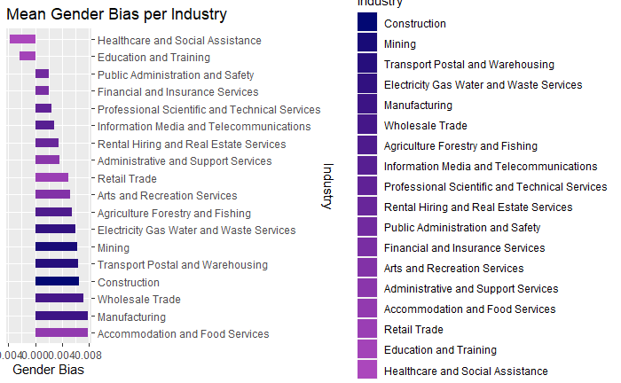

```r
cols_ratio <- c("Construction" = "#020873", "Mining" = "#180b77", "Transport Postal and Warehousing" = "#260e7c", "Electricity Gas Water and Waste Services" = "#311180", "Manufacturing" = "#3c1485", "Wholesale Trade" = "#451789", "Agriculture Forestry and Fishing" = "#4e1b8d",  "Information Media and Telecommunications" = "#571f92", "Professional Scientific and Technical Services" = "#602296", "Rental Hiring and Real Estate Services" = "#68269a", "Public Administration and Safety" = "#712a9f", "Financial and Insurance Services" = "#792ea3", "Arts and Recreation Services" = "#8232a7",  "Administrative and Support Services" = "#8a36ab", "Accommodation and Food Services" = "#923aaf", "Retail Trade" = "#9a3eb4", "Education and Training" = "#a343b8", "Healthcare and Social Assistance" = "#ab47bc")

ggplot(data_bias, aes(x= reorder(Industry, -man_woman), y=man_woman, label=man_woman, fill = Industry)) +
  geom_bar(stat='summary', width=.5)  +
  scale_x_discrete(position = "top")+
  coord_flip()+
  labs(title="Mean Gender Bias per Industry", y = "Gender Bias", x = "Industry") +
  scale_fill_manual(values = cols_ratio)
```

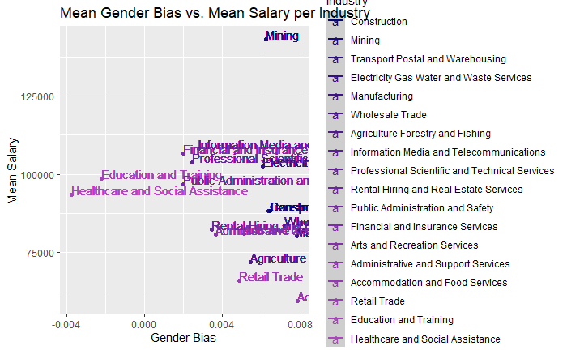

```r
data_bias %>% group_by(Industry) %>%
  ggplot(aes(mean_bias,salary_mean2020, color=Industry)) +
  geom_point()+
  geom_smooth(method = "lm")+
  geom_text(aes(label=Industry),hjust=0, vjust=0)+
  labs(title="Mean Gender Bias vs. Mean Salary per Industry", y = "Mean Salary", x = "Gender Bias") +
  scale_colour_manual(values = cols_ratio)
```

```r
cor.test(data_bias$salary_mean2020, data_bias$mean_bias, method=c("pearson"))
```

```r
data_bias %>% group_by(Industry) %>%
  ggplot(aes(Ratio,salary_mean2020, color=Industry)) +
  geom_point()+
  geom_smooth(method = "lm")+
  geom_text(aes(label=Industry),hjust=0, vjust=0)+
  labs(title="Gender Ratio vs. Mean Salary per Industry", y = "Mean Salary", x = "Gender Ratio") +
  scale_colour_manual(values = cols_ratio)
```

```r
cor.test(data_bias$salary_mean2020, data_bias$Ratio, method=c("pearson"))
```

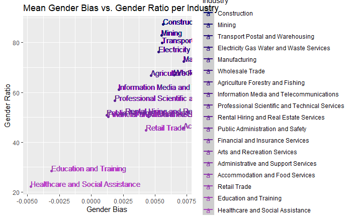

```r
data_bias %>% group_by(Industry) %>%
  ggplot(aes(mean_bias,Ratio, color=Industry)) +
  geom_point()+
  geom_smooth(method = "lm")+
  geom_text(aes(label=Industry),hjust=0, vjust=0)+
  labs(title="Mean Gender Bias vs. Gender Ratio per Industry", y = "Gender Ratio", x = "Gender Bias") +
  scale_colour_manual(values = cols_ratio)
```

```r
cor.test(data_bias$salary_mean2020, data_bias$mean_bias, method=c("pearson"))
```

### —- Plotting bias against gender ratio in industry —

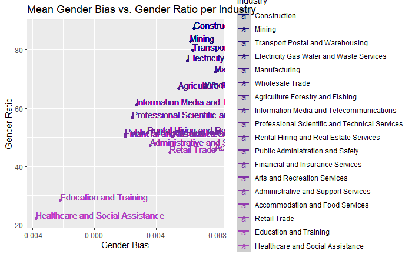

```r
#ggthemr_reset()

cols_ratio <- c("Construction" = "#020873", "Mining" = "#180b77", "Transport Postal and Warehousing" = "#260e7c", "Electricity Gas Water and Waste Services" = "#311180", "Manufacturing" = "#3c1485", "Wholesale Trade" = "#451789", "Agriculture Forestry and Fishing" = "#4e1b8d",  "Information Media and Telecommunications" = "#571f92", "Professional Scientific and Technical Services" = "#602296", "Rental Hiring and Real Estate Services" = "#68269a", "Public Administration and Safety" = "#712a9f", "Financial and Insurance Services" = "#792ea3", "Arts and Recreation Services" = "#8232a7", "Administrative and Support Services" = "#8a36ab", "Accommodation and Food Services" = "#923aaf", "Retail Trade" = "#9a3eb4", "Education and Training" = "#a343b8", "Healthcare and Social Assistance" = "#ab47bc")


data_bias %>% group_by(Industry) %>%
  ggplot(aes(mean_bias,Ratio, color=Industry)) +
  geom_point()+
  geom_smooth(method = "lm")+
  geom_text(aes(label=Industry),hjust=0, vjust=0)+
  labs(title="Mean Gender Bias vs. Gender Ratio per Industry", y = "Gender Ratio", x = "Gender Bias") +
  scale_colour_manual(values = cols_ratio)
```

```r
data_bias %>% group_by(Industry) %>%
  ggplot(aes(salary_mean,Ratio, color=Industry)) +
  geom_point(stat='summary')+
  geom_smooth(method = "lm")+
  geom_text(aes(label=Industry),hjust=0, vjust=0)+
  labs(title="Indeed Data: Gender Bias / Gender Ratio - Plot", y = "Gender Bias", x = "Industry") +
  scale_colour_manual(values = cols_ratio)
```

```r
data_bias %>% group_by(Industry) %>%
  ggplot(aes(mean_bias,rating_average, color=Industry)) +
  geom_point()+
  geom_smooth(method = "lm")+
  geom_text(aes(label=Industry),hjust=0, vjust=0)+
  labs(title="Plot - Gender Bias vs. Average Rating per Industry", y = "Average Rating", x = "Gender Bias")+
  scale_colour_manual(values = cols_ratio)
```

```r
cor.test(data_bias$rating_average, data_bias$mean_bias, method=c("pearson"))
```

```r
lm_rat <- lm(rating_average ~ mean_bias, data_bias)
summary(lm_rat)
```

```r
cor.test(data_bias$Ratio, data_bias$rating_average, method=c("pearson"))
```

```r
lm_rat_ratio <- lm(rating_average ~ Ratio, data_bias)
summary(lm_rat_ratio)
```

```r
data_bias %>% group_by(Industry) %>%
  ggplot(aes(Ratio,rating_average, color=Industry)) +
  geom_point()+
  geom_smooth(method = "lm")+
  geom_text(aes(label=Industry),hjust=0, vjust=0)+
  labs(title="Gender Bias / Average Rating - Plot", y = "Average Rating", x = "Gender Ratio")+
  scale_colour_manual(values = cols_ratio)
```

```
No summary function supplied, defaulting to `mean_se()`
```

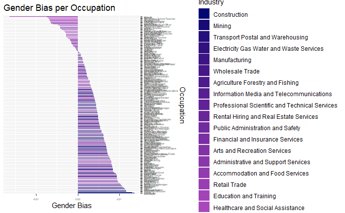

```r
# call in dataset where occupations are not duplicated
data_occ <- read.csv("dataset_final_google_occupations.csv")

#plot
gg_occ <- ggplot(data_occ, aes(x= reorder(Occupation, -man_woman), y=man_woman, label=man_woman, fill=Industry)) +
  geom_bar(stat='summary', width=.5)  +
  scale_x_discrete(position = "top")+
  coord_flip()+
scale_fill_manual(values = cols_ratio) +
  labs(title="Gender Bias per Occupation", y = "Gender Bias", x = "Occupation")


gg_occ + theme(axis.text = element_text(size = 4))
```

```r
occ_order <- data_bias %>%
  group_by(Occupation) %>%
  summarise(mean(man_woman))

print(occ_order)
```

| Occupation | mean(man_woman) |
| --- | --- |
| Accountant | 4.850338e-03 |
| Accounting Clerk | 1.258602e-03 |
| Actor | 5.622411e-03 |
| Advertising | -7.851568e-05 |
| Aged Care | -6.453707e-03 |
| Agricultural Science | 1.950761e-03 |
| Air Transport | 6.479072e-03 |
| Amusement Work | 8.633602e-03 |
| Application Programmer | 6.874562e-03 |
| Architect | 3.823263e-03 |

[output cut: 197 more lines]

```r
write.csv(occ_order,"occ_order_new1.csv")
```

### —- Top 10 of each most biased job description - their occupations —

```
No summary function supplied, defaulting to `mean_se()`
```

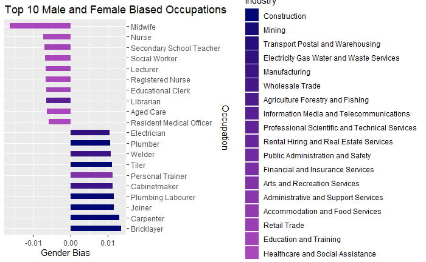

```r
data_top10 <- read_csv("dataset_final_google_occupation_top10.csv")
ggplot(data_top10, aes(x= reorder(Occupation, -man_woman), y=man_woman, label=man_woman, fill=Industry)) +
  geom_bar(stat='summary', width=.5)  +
  scale_x_discrete(position = "top")+
  coord_flip()+
  scale_fill_manual(values = cols_ratio) +
  labs(title="Top 10 Male and Female Biased Occupations", y = "Gender Bias", x = "Occupation")
```

```r
install.packages('ggthemes')
library("ggthemes")

ggplot(data_top10, aes(x= reorder(Occupation, -man_woman), y=man_woman, label=man_woman, fill=Occupation)) +
  geom_bar(stat='summary', width=.5)  +
  scale_x_discrete(position = "top")+
  coord_flip() +
  theme_pander() +
  scale_fill_pander()
```

### — Top 5 highest ratio plot — ### (compare with above)

Stats on the top 5 most Ratio men/women industries: Male: Overall proportion across all industries = 57.65% 1. Construction (87.3%) 2. Mining (83%) 3. Transport, postal and warehousing (79.8%) 4. Electricity, gas, water and waste services (76.2%) 5. Manufacturing (72.5%)

Female: Overall proportion across all industries = 42.35% 1. Health care and social assistance (77.9%) 2. Education and training (71.6%) 3. Retail trade (55.2%) 4. Accommodation and food services (54.5%) 5. Administrative and support services (52.9%)

Most biased according to data (mean bias per industry): Male: 1. Accommodation and Food Services 2. Manufacturing 3. Wholesale Trade 4. Construction 5. Transport Postal and Warehousing

Female: 1. Healthcare and Social Assistance (only female) 2. Education and Training (only female) 3. Public Administration and Safety 4. Financial and Insurance Services 5. Professional Scientific and Technical Services !!! << this is interesting in terms of STEM, maybe we are seeing a change here!

### — Plots of occupations within subsets of Industries, see how they compare to the mean —

```r
#ggthemr_reset()

library("ggthemes")


ggplot(in1, aes(x= reorder(Occupation, -man_woman), y=man_woman, label=man_woman, fill = Occupation)) +
  geom_bar(stat='summary', width=.5)  +
  xlim(-0.5, 0.5) +
  coord_flip()+
  labs(title="Occupation by Gender Bias - Accommodation and Food Services", y = "Gender Bias", x = "Occupation") +
  theme_pander() +
  scale_fill_pander()
```

```
Error: Discrete value supplied to continuous scale
```

```r
ggplot(in2, aes(x= reorder(Occupation, -man_woman), y=man_woman, label=man_woman, fill = Occupation)) +
  geom_bar(stat='summary', width=.5)  +
  scale_x_discrete(position = "top")+
  coord_flip()+
  labs(title="Occupation by Gender Bias - Agriculture Forestry and Fishing", y = "Gender Bias", x = "Occupation") +
  theme_pander() +
  scale_fill_pander()
```

```
No summary function supplied, defaulting to `mean_se()`
```

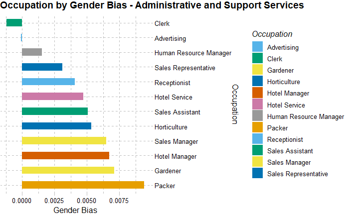

```r
ggplot(in22, aes(x= reorder(Occupation, -man_woman), y=man_woman, label=man_woman, fill = Occupation)) +
  geom_bar(stat='summary', width=.5)  +
  scale_x_discrete(position = "top")+
  coord_flip()+
  labs(title="Occupation by Gender Bias - Administrative and Support Services", y = "Gender Bias", x = "Occupation")+
  theme_pander() +
  scale_fill_pander()
```

```r
ggplot(in4, aes(x= reorder(Occupation, -man_woman), y=man_woman, label=man_woman, fill = Occupation)) +
  geom_bar(stat='summary', width=.5)  +
  scale_x_discrete(position = "top")+
  coord_flip()+
  labs(title="Occupation by Gender Bias - Construction", y = "Gender Bias", x = "Occupation")+
  theme_pander() +
  scale_fill_pander()
```

```r
ggplot(in22, aes(x= reorder(Occupation, -man_woman), y=man_woman, label=man_woman, fill = Occupation)) +
  geom_bar(stat='summary', width=.5)  +
  scale_x_discrete(position = "top")+
  coord_flip()+
  labs(title="Occupation by Gender Bias - Administrative and Support Services", y = "Gender Bias", x = "Occupation")+
  theme_pander() +
  scale_fill_pander()
```

```r
ggplot(in5, aes(x= reorder(Occupation, -man_woman), y=man_woman, label=man_woman, fill = Occupation)) +
  geom_bar(stat='summary', width=.5)  +
  scale_x_discrete(position = "top")+
  coord_flip()+
  labs(title="Occupation by Gender Bias - Education and Training", y = "Gender Bias", x = "Occupation") +
  theme_pander() +
  scale_fill_pander()
```

```r
ggplot(in6, aes(x= reorder(Occupation, -man_woman), y=man_woman, label=man_woman, fill = Occupation)) +
  geom_bar(stat='summary', width=.5)  +
  scale_x_discrete(position = "top")+
  coord_flip()+
  labs(title="Occupation by Gender Bias - Electricity Gas Water and Waste Services", y = "Gender Bias", x = "Occupation")  +
  theme_pander() +
  scale_fill_pander()
```

```r
ggplot(in7, aes(x= reorder(Occupation, -man_woman), y=man_woman, label=man_woman, fill = Occupation)) +
  geom_bar(stat='summary', width=.5)  +
  scale_x_discrete(position = "top")+
  coord_flip()+
  labs(title="Occupation by Gender Bias - Financial and Insurance Services", y = "Gender Bias", x = "Occupation")  +
  theme_pander() +
  scale_fill_pander()
```

```r
ggplot(in8, aes(x= reorder(Occupation, -man_woman), y=man_woman, label=man_woman, fill = Occupation)) +
  geom_bar(stat='summary', width=.5)  +
  scale_x_discrete(position = "top")+
  coord_flip()+
  labs(title="Occupation by Gender Bias - Healthcare and Social Assistance", y = "Gender Bias", x = "Occupation") +
  theme_pander() +
  scale_fill_pander()
```

```r
ggplot(in9, aes(x= reorder(Occupation, -man_woman), y=man_woman, label=man_woman, fill = Occupation)) +
  geom_bar(stat='summary', width=.5)  +
  scale_x_discrete(position = "top")+
  coord_flip()+
  labs(title="Occupation by Gender Bias - Information Media and Telecommunications", y = "Gender Bias", x = "Occupation") +
  theme_pander() +
  scale_fill_pander()
```

```r
ggplot(in10, aes(x= reorder(Occupation, -man_woman), y=man_woman, label=man_woman, fill = Occupation)) +
  geom_bar(stat='summary', width=.5)  +
  scale_x_discrete(position = "top")+
  coord_flip()+
  labs(title="Occupation by Gender Bias - Manufacturing", y = "Gender Bias", x = "Occupation") +
  theme_pander() +
  scale_fill_pander()
```

```r
ggplot(in11, aes(x= reorder(Occupation, -man_woman), y=man_woman, label=man_woman, fill = Occupation)) +
  geom_bar(stat='summary', width=.5)  +
  scale_x_discrete(position = "top")+
  coord_flip()+
  labs(title="Occupation by Gender Bias - Mining", y = "Gender Bias", x = "Occupation") +
  theme_pander() +
  scale_fill_pander()
```

```r
ggplot(in12, aes(x= reorder(Occupation, -man_woman), y=man_woman, label=man_woman, fill = Occupation)) +
  geom_bar(stat='summary', width=.5)  +
  scale_x_discrete(position = "top")+
  coord_flip()+
  labs(title="Occupation by Gender Bias - Professional Scientific and Technical Services", y = "Gender Bias", x = "Occupation") +
  theme_pander() +
  scale_fill_pander()
```

```r
ggplot(in13, aes(x= reorder(Occupation, -man_woman), y=man_woman, label=man_woman, fill = Occupation)) +
  geom_bar(stat='summary', width=.5)  +
  scale_x_discrete(position = "top")+
  coord_flip()+
  labs(title="Occupation by Gender Bias - Public Administration and Safety", y = "Gender Bias", x = "Occupation") +
  theme_pander() +
  scale_fill_pander()
```

```r
ggplot(in14, aes(x= reorder(Occupation, -man_woman), y=man_woman, label=man_woman, fill = Occupation)) +
  geom_bar(stat='summary', width=.5)  +
  scale_x_discrete(position = "top")+
  coord_flip()+
  labs(title="Occupation by Gender Bias - Rental Hiring and Real Estate Services", y = "Gender Bias", x = "Occupation") +
  theme_pander() +
  scale_fill_pander()
```

```r
ggplot(in15, aes(x= reorder(Occupation, -man_woman), y=man_woman, label=man_woman, fill = Occupation)) +
  geom_bar(stat='summary', width=.5)  +
  scale_x_discrete(position = "top")+
  coord_flip()+
  labs(title="Occupation by Gender Bias - Retail Trade", y = "Gender Bias", x = "Occupation") +
  theme_pander() +
  scale_fill_pander()
```

```r
ggplot(in16, aes(x= reorder(Occupation, -man_woman), y=man_woman, label=man_woman, fill = Occupation)) +
  geom_bar(stat='summary', width=.5)  +
  scale_x_discrete(position = "top")+
  coord_flip()+
  labs(title="Occupation by Gender Bias - Transport Postal and Warehousing", y = "Gender Bias", x = "Occupation") +
  theme_pander() +
  scale_fill_pander()
```

```r
ggplot(in17, aes(x= reorder(Occupation, -man_woman), y=man_woman, label=man_woman, fill = Occupation)) +
  geom_bar(stat='summary', width=.5)  +
  scale_x_discrete(position = "top")+
  coord_flip()+
  labs(title="Occupation by Gender Bias - Wholesale Trade", y = "Gender Bias", x = "Occupation")  +
  theme_pander() +
  scale_fill_pander()
```

### — Plotting GPG per Industry against bias, ratio etc —-

```r
data_bias %>% group_by(Industry) %>%
  ggplot(aes(mean_bias,gpg, color=Industry)) +
  geom_point()+
  geom_smooth(method = "lm")+
  geom_text(aes(label=Industry),hjust=0, vjust=0)+
  labs(title="Average Gender Bias vs. GPG per Industry", y = "GPG", x = "Average Gender Bias")+
  scale_colour_manual(values = cols_ratio)
```

```r
cor.test(data_bias$gpg, data_bias$mean_bias, method=c("pearson"))
```

```r
data_bias %>% group_by(Industry) %>%
  ggplot(aes(Ratio,gpg, color=Industry)) +
  geom_point()+
  geom_smooth(method = "lm")+
  geom_text(aes(label=Industry),hjust=0, vjust=0)+
  labs(title="Gender Ratio vs. GPG per Industry", y = "GPG", x = "Ratio")+
  scale_colour_manual(values = cols_ratio)
```

```r
cor.test(data_bias$gpg, data_bias$Ratio, method=c("pearson"))
```

```r
## extracting which rows have the most biased words

ws <- data_bias[grep("'brilliance'", data_bias$clean), ]

ws <- subset(ws, select=c("Job Title", "Occupation", "Industry", "Job Description", "clean"))

ws %>%
  group_by(Industry) %>%
  print(ws)

write_csv(ws,"brilliance.csv")
```

```r
#df %>% group_by("Amount") %>% slice(which.min(x))

data_bias %>%
  group_by("Occupation") %>%
  data_bias[which(data_bias$clean == "hero"), ]
```

```r
frequency_dataframe = new_df %>% count(word) %>% arrange(desc(n))
```

[output not shown]